# Mimir Compactor PVC Pressure

Current forensic trace: Grafana event to governed GitOps remediation

A request-by-request forensic trace of a governed Mimir compactor PVC remediation, including identity, operation references, Postgres state, Git recovery, and executable invariants.

Author

Observability Platform Engineering

Published

July 16, 2026

This is a slow-motion trace of one concrete operation. Grafana reports pressure on a Mimir compactor PVC. Kestra sequences typed HTTP calls. The gateway derives identity, obtains a bounded plan, evaluates policy, binds approval, and makes recoverable provider calls. Git remains the production mutation boundary. Postgres, not Kestra or the model, owns durable operation authority.

**ImportantCurrent implementation**

This edition describes the invariant-kernel implementation at source revision `d6c5046`. After policy, Kestra no longer copies every prior response into every request. Policy returns a caller-bound `operationRef`; later routes send that handle, and the gateway reloads the server-owned snapshot from Postgres. The catalog is a compiled, digest-verified runtime artifact, and Git publication recovers by exact semantic readback.

## Read this first

The execution has three phases:

| Phase | What crosses the wire | What becomes authoritative |
| --- | --- | --- |
| **Understand** | Grafana event, then complete evidence and plan components | Typed evidence, plan, policy, and immutable identity |
| **Authorize** | One compact `operationRef` | Server-owned snapshot, approval binding, preflight binding |
| **Act and prove** | The same `operationRef` plus route metadata | Outbox state, exact Git objects, provider correlation, Argo readback, audit chain |

[figure not shown]

**Figure 1.** Full components are carried only through policy. Policy issues the compact operation reference. Every later route resolves it to server-owned state and rejects component substitution, a foreign caller, or an out-of-order call. Click for full resolution.

**NoteTwo correction points**

The first trigger is the Grafana webhook, not the reconciliation sweep. The sweep only revisits operations already known to the gateway. The model is not an autonomous Kubernetes agent: it is one provider call inside planning and holds no Git, Kubernetes, ITSM, incident, or database credentials.

## What runs where

| Component | Runtime | Reads | Writes | Authority |
| --- | --- | --- | --- | --- |
| Grafana alerting | Observability plane | Metrics and alert rules | Webhook delivery | Detect and notify |
| Kestra | Automation namespace | Trigger body and gateway responses | Execution history | Sequence and retry tasks |
| Planner gateway | Multi-replica Kubernetes Deployment | Compiled catalog, OPA, Postgres, approved APIs | Typed state and bounded provider calls | Validate, authorize, correlate, recover |
| Model provider | External approved API | Sanitized evidence and catalog-bounded prompt | Typed plan proposal | Propose only |
| OPA | Gateway policy boundary | Evidence, plan, catalog, runtime facts | Allow or deny | Deny unsafe intent |
| Postgres | Managed database, dedicated gateway schema | Durable records | Attempts, snapshots, outbox, audit, compensation | Operation authority and recovery |
| Git provider | Enterprise Git service | Base ref and target file | Deterministic branch, commit, draft PR | Change system of record |
| Human reviewer | Existing pull-request process | Evidence and exact diff | Review and merge decision | Final production authorization |
| Argo CD | Existing GitOps control plane | Approved Git revision | Kubernetes reconciliation | Apply merged desired state |

Kestra stores its execution graph and task outputs in the Kestra database. The gateway stores safety-critical state in a separate gateway schema. Kestra can show what task ran; it is not the authority for whether an external effect may run again.

# 1. Detection and ingress

## Grafana routing

```
Grafana alert rule
  -> notification policy
  -> webhook contact point
  -> Kestra Webhook trigger
  -> catalog_remediation_aiops execution
```

The contact point uses this URL shape:

```
https://kestra.example.com/api/v1/main/executions/webhook/
aiops.kestra/catalog_remediation_aiops/<secret-webhook-key>
```

The canonical flow declares:

```yaml
triggers:
  - id: alertmanager_webhook
    type: io.kestra.plugin.core.trigger.Webhook
    key: __KESTRA_WEBHOOK_KEY__
    wait: false
    returnOutputs: false
```

`wait: false` acknowledges ingress without waiting for planning, approval, Git, or verification. The workflow continues asynchronously.

## Exact webhook delivery

One Grafana delivery can contain one alert instance or a notification group. The repository fixture contains one instance:

```json
{
  "version": "4",
  "receiver": "aiops-kestra-webhook",
  "status": "firing",
  "catalogEntryId": "mimir.compactor.pvc-pressure",
  "groupKey": "{}/{alertname=\\"MimirCompactorPVCPressure\\"}:{}",
  "commonLabels": {
    "alertname": "MimirCompactorPVCPressure",
    "cluster": "contextual-cellgroup-a",
    "cell_id": "contextual-cell-a",
    "namespace": "mimir",
    "workload": "mimir-compactor",
    "persistentvolumeclaim": "mimir-compactor-data"
  },
  "alerts": [
    {
      "status": "firing",
      "fingerprint": "grafana-labels-fingerprint-9d8c7b6a",
      "startsAt": "2026-07-01T18:00:00Z",
      "labels": {
        "alertname": "MimirCompactorPVCPressure",
        "cluster": "contextual-cellgroup-a",
        "cell_id": "contextual-cell-a",
        "namespace": "mimir",
        "workload": "mimir-compactor",
        "persistentvolumeclaim": "mimir-compactor-data",
        "severity": "warning"
      },
      "annotations": {
        "summary": "Mimir compactor PVC pressure",
        "description": "Mimir compactor PVC has less than 15 percent free capacity."
      }
    }
  ]
}
```

The native Grafana fingerprint is evidence about the alert instance. It is not the universal key because it does not encode catalog meaning, repository, requested change, approval, or external operation type.

# 2. Compiled remediation contract

The reviewed catalog source defines what the condition means and what a safe response may contain:

```yaml
id: mimir.compactor.pvc-pressure
title: Mimir compactor PVC pressure
component: mimir-compactor
statefulness: stateful
riskRating: medium
triggerSources:
  - grafana.alertmanager
  - scheduled.sweep
signals:
  - alertname: MimirCompactorPVCPressure
  - promql: kubelet_volume_stats_used_bytes / kubelet_volume_stats_capacity_bytes > 0.85
allowedPrActions:
  - update_helm_value
  - increase_pvc_size
  - increase_resource_request
prTarget:
  repository: observability-gitops
  pathTemplate: clusters/{{ cluster }}/namespaces/{{ namespace }}/mimir/values.yaml
  fields:
    - compactor.persistentVolume.size
    - compactor.resources.requests
    - compactor.resources.limits
costControls:
  maxPvcIncreasePercent: 50
  maxPvcSize: 1Ti
approval:
  production: required
```

Production does not reinterpret YAML on every request. The build compiles all 31 entries into one deterministic artifact:

| Artifact | Current value |
| --- | --- |
| Reviewed source | `catalog/remediation-catalog.yaml` |
| Compiler | `scripts/compile_remediation_catalog.py` |
| Runtime bundle | `catalog/remediation-catalog.compiled.json` |
| Bundle format | `aiops.remediation-catalog.compiled.v1` |
| Source SHA-256 | `80b918afb1d5f56b2b12ced0aa09c9ddde66a01e5a262343d837a84ef406a255` |
| Canonical payload digest | `a906f9333b575ba457054aa146e22d3994a04f9ae3af3125faa71cd13f988c59` |

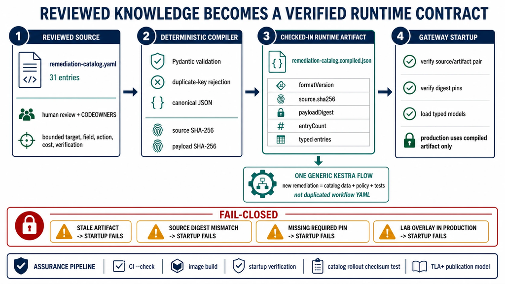

**Figure 2.** Humans review YAML; CI compiles one canonical JSON bundle; the gateway verifies source and payload digests at startup. Production rejects a stale bundle, changed source, duplicate keys, noncanonical JSON, source mode, and lab overlays.

# 3. Canonical execution

## Transport and persistence map

| Step | Kestra request | Gateway response | Durable effect |
| --- | --- | --- | --- |
| 1 | Raw Grafana event to `/v1/evidence` | Typed evidence | Evidence component and identities |
| 2 | Evidence to `/v1/plan` | Typed proposal | Plan component |
| 3 | Evidence + plan to `/v1/policy` | Policy + `operationRef` | Operation snapshot revision 1 |
| 4 | `operationRef` to `/v1/approval/request` | Bound approval | Attempt, approval, snapshot revision |
| 5 | `operationRef` to `/v1/providers/preflight` | Route admission | Preflight and snapshot revision |
| 6 | `operationRef` to `/v1/gitops/pr` | Exact draft PR | Outbox, Git objects, snapshot revision |
| 7 | `operationRef` to `/v1/providers/notify` | Fanout result | One correlated object per sink |
| 8 | `operationRef` to `/v1/argo/verify` | Revision-bound observation | Read-only verification |
| 9 | `operationRef` plus metadata to `/v1/audit` | Audit bundle | Latest projection and hash-chained event |

The flow has concurrency limit 8 with `QUEUE`. Kestra owns a small transport retry budget. The gateway and Postgres own provider-attempt eligibility.

## Step 1: evidence

1

### Normalize the notification

Kestra sends the external event. The gateway selects the catalog, redacts unsafe fields, derives topology and alert lineage, and reads the authoritative current Git value.

```
POST /v1/evidence
X-AIOPS-Gateway-Token: [redacted]
Content-Type: application/json
```

```json
{
  "alert": {
    "version": "4",
    "catalogEntryId": "mimir.compactor.pvc-pressure",
    "alerts": [{
      "fingerprint": "grafana-labels-fingerprint-9d8c7b6a",
      "labels": {
        "cluster": "contextual-cellgroup-a",
        "cell_id": "contextual-cell-a",
        "namespace": "mimir",
        "workload": "mimir-compactor",
        "persistentvolumeclaim": "mimir-compactor-data"
      }
    }]
  }
}
```

Representative material response:

```json
{
  "catalogEntryId": "mimir.compactor.pvc-pressure",
  "cluster": "contextual-cellgroup-a",
  "cellId": "contextual-cell-a",
  "namespace": "mimir",
  "workload": "mimir-compactor",
  "sensitiveDataIncluded": false,
  "gitopsAuthoritativeCurrent": {
    "repository": "observability-gitops",
    "baseBranch": "main",
    "targetPath": "clusters/contextual-cellgroup-a/namespaces/mimir/mimir/values.yaml",
    "field": "compactor.persistentVolume.size",
    "value": "200Gi"
  },
  "identity": {
    "alertFingerprint": "alert:v1:2cacc6298d7fd96fec6e4296e8dc5794",
    "resourceScopeKey": "remediation:v1:ee5b4d4297b1242f6dfd9b33ec6217b4",
    "caseKey": "case:v1:6b0fa0d60c77c1ac5a9202a01c05b4d3",
    "auditCaseKey": "audit:v1:9c3cff8c38974c415bdad7075e4cbc7b"
  }
}
```

## Step 2: plan

2

### Request one bounded proposal

Kestra sends typed evidence. The gateway adds selected catalog context, calls the configured planner, and validates a typed PlanComponent.

```yaml
body: |
  {
    "evidence": {{ outputs.collect_evidence.body | jq('.') | first }}
  }
```

```json
{
  "catalogEntryId": "mimir.compactor.pvc-pressure",
  "provider": "anthropic",
  "llmUsed": true,
  "decision": "propose_gitops_pr",
  "confidence": "medium",
  "proposedChange": {
    "action": "increase_pvc_size",
    "targetRepository": "observability-gitops",
    "targetPath": "clusters/contextual-cellgroup-a/namespaces/mimir/mimir/values.yaml",
    "field": "compactor.persistentVolume.size",
    "currentValue": "200Gi",
    "proposedValue": "300Gi",
    "directMutation": false
  },
  "verification": [
    "PVC utilization falls below 75 percent",
    "Mimir compactor succeeds within 30 minutes",
    "Argo CD reports Synced and Healthy"
  ]
}
```

The model can propose only. Its response must match the schema and then survive deterministic policy. Model credentials cannot write to Git or Kubernetes.

## Step 3: policy and operation reference

3

### Evaluate semantics and issue a durable handle

Kestra sends evidence and plan. OPA evaluates the catalog boundary. The gateway persists the initial server-owned snapshot and returns its operation reference.

```yaml
body: |
  {
    "evidence": {{ outputs.collect_evidence.body | jq('.') | first }},
    "plan": {{ outputs.planner.body | jq('.') | first }}
  }
```

Policy checks the kill switch, action allowlist, exact repository/path/field, direct-mutation flag, PVC direction, 50 percent cap, 1 TiB maximum, topology, and sensitive-data boundary.

```json
{
  "catalogEntryId": "mimir.compactor.pvc-pressure",
  "decision": "allow",
  "violations": [],
  "enforcedBoundary": "gitops_pull_request",
  "forbiddenActions": [
    "direct_kubectl_apply",
    "direct_kubectl_patch",
    "direct_kubectl_delete",
    "direct_shell",
    "direct_ssh",
    "shrink_pvc",
    "merge_own_pr"
  ],
  "killSwitchEnabled": false,
  "operationRef": "operation-ref:v1:48619c00cce83a5cb797d3188cdf2225"
}
```

### How the operation reference is created

```json
{
  "attemptKey": "attempt:v1:c6a3967e3d020c213af8697c45487dbf",
  "issuedComponentKey": "audit:v1:9c3cff8c38974c415bdad7075e4cbc7b",
  "schemaVersion": "aiops.operation-snapshot.v1"
}
```

```
SHA-256:
48619c00cce83a5cb797d3188cdf222595564faf410c832b9b89bf5f0bb16fd7

Public handle:
operation-ref:v1:48619c00cce83a5cb797d3188cdf2225
```

The snapshot is stored as:

```
aiops_state_records
  category        = operationSnapshots
  idempotency_key = operation-ref:v1:48619c00cce83a5cb797d3188cdf2225
```

```json
{
  "schemaVersion": "aiops.operation-snapshot.v1",
  "operationRef": "operation-ref:v1:48619c00cce83a5cb797d3188cdf2225",
  "attemptKey": "attempt:v1:c6a3967e3d020c213af8697c45487dbf",
  "issuedComponentKey": "audit:v1:9c3cff8c38974c415bdad7075e4cbc7b",
  "ownerCallerId": "shared-secret",
  "initialContextDigest": "[SHA-256 binding]",
  "context": {
    "evidence": {"catalogEntryId": "mimir.compactor.pvc-pressure"},
    "plan": {"decision": "propose_gitops_pr"},
    "policy": {"decision": "allow"}
  },
  "componentDigests": {
    "evidence": "[evidence intent digest]",
    "plan": "[plan intent digest]",
    "policy": "[policy intent digest]"
  },
  "completedRoutes": ["/policy"],
  "revision": 1
}
```

The canonical flow uses the shared gateway token, so this fixture’s caller is `shared-secret`. When per-caller authentication is enabled, the gateway instead authenticates `X-AIOPS-Caller-Id` against that caller’s token and binds the handle to the resulting identity. A caller cannot use another caller’s handle.

**ImportantWhat the handle is not**

The operation snapshot is a convenience projection, not side-effect authority. It prevents Kestra from resending and substituting prior components. External effect authority still lives in attempt and outbox records plus exact provider readback.

## Step 4: approval

4

### Bind a human decision to one immutable intent

Kestra sends only the handle. The gateway reloads evidence, plan, and policy from Postgres, requires policy to be complete, and issues or replays approval.

```json
{
  "operationRef": "operation-ref:v1:48619c00cce83a5cb797d3188cdf2225"
}
```

| Binding field | What it prevents |
| --- | --- |
| `caseKey` | Reuse for a different recurring case |
| `catalogHash` | Acting after the catalog changed |
| `evidenceHash` | Evidence substitution |
| `planHash` | Target, field, action, or value substitution |
| `policyHash` | Reuse from another policy result |
| `changeIntentHash` | Changing the exact Git change |
| `attemptKey` | Reuse across attempts |
| Expiry and evidence age | Stale authorization |

```json
{
  "approved": true,
  "idempotencyKey": "attempt:v1:c6a3967e3d020c213af8697c45487dbf",
  "approvalBinding": {
    "caseKey": "case:v1:6b0fa0d60c77c1ac5a9202a01c05b4d3",
    "changeIntentHash": "change-intent:v1:724ed65eab3197d755832a61f894bad8",
    "remediationAttemptId": "attempt:v1:c6a3967e3d020c213af8697c45487dbf"
  },
  "operationRef": "operation-ref:v1:48619c00cce83a5cb797d3188cdf2225"
}
```

A committed manual decision is terminal. An identical retry replays it; an attempted reversal is rejected.

## Step 5: provider preflight

5

### Admit routes before any external write

The same handle resolves to approved context. The gateway evaluates sink routing and connectivity without creating a PR, ITSM record, or incident.

```json
{
  "operationRef": "operation-ref:v1:48619c00cce83a5cb797d3188cdf2225"
}
```

```json
{
  "catalogEntryId": "mimir.compactor.pvc-pressure",
  "idempotencyKey": "attempt:v1:c6a3967e3d020c213af8697c45487dbf",
  "decision": "allow",
  "checks": [
    {
      "provider": "servicenow",
      "role": "itsm",
      "required": true,
      "status": "passed",
      "sideEffectCreated": false
    },
    {
      "provider": "pagerduty",
      "role": "incident",
      "required": true,
      "status": "passed",
      "sideEffectCreated": false
    }
  ],
  "violations": [],
  "directMutation": false,
  "operationRef": "operation-ref:v1:48619c00cce83a5cb797d3188cdf2225"
}
```

Preflight is admission evidence, not proof that a later write will succeed. Credentials can be revoked after preflight; the outbox still models partial and ambiguous outcomes.

## Step 6: exact draft GitOps PR

6

### Record intent, then publish exact Git objects

The handle resolves to approved state. The gateway prepares exact repository, base, tree, commit, branch, and diff coordinates, records the outbox intent, then calls Git.

Request:

```json
{
  "operationRef": "operation-ref:v1:48619c00cce83a5cb797d3188cdf2225"
}
```

Approved change:

```
 compactor:
   persistentVolume:
-    size: 200Gi
+    size: 300Gi
```

The external-operation key is:

```
side-effect:v1:e9b366fc109fedbbf9507a3ff6c19ae6
```

The outbox record exists before the provider call. It binds the prepared proposal and progresses through fenced states such as pending, claimed, unknown external state, completed, failed, or dead letter.

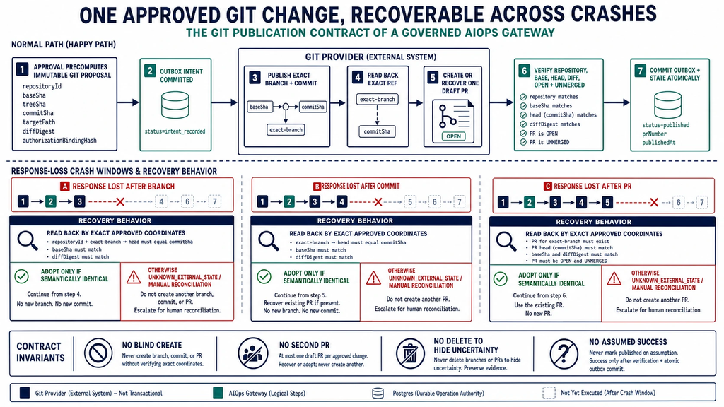

**Figure 3.** Response loss after branch, commit, or pull-request creation does not authorize another blind create. Recovery reads the exact approved coordinates and either proves the existing object, retains explicit ambiguity, or fails closed.

Representative provider response for this fixture:

```json
{
  "created": true,
  "directMutation": false,
  "provider": "github",
  "catalogEntryId": "mimir.compactor.pvc-pressure",
  "repository": "observability-gitops",
  "baseBranch": "main",
  "branch": "aiops/mimir-compactor-pvc-pressure-e9b366fc",
  "targetPath": "clusters/contextual-cellgroup-a/namespaces/mimir/mimir/values.yaml",
  "prNumber": 82,
  "requiresHumanApproval": true,
  "autoMerge": false,
  "allowsSelfMerge": false,
  "idempotencyKey": "side-effect:v1:e9b366fc109fedbbf9507a3ff6c19ae6",
  "operationRef": "operation-ref:v1:48619c00cce83a5cb797d3188cdf2225"
}
```

The gateway does not merge its own PR. Branch protection, ownership, review, and merge remain external controls.

## Step 7: provider notifications

The fanout call carries only the handle:

```json
{
  "operationRef": "operation-ref:v1:48619c00cce83a5cb797d3188cdf2225"
}
```

The gateway reloads the completed Git result, uses the preflight-admitted sink routes, derives one operation key per sink, and persists an outbox record before each write.

```json
{
  "schemaVersion": "aiops.provider-notification-fanout.v1",
  "catalogEntryId": "mimir.compactor.pvc-pressure",
  "decision": "allow",
  "created": true,
  "directMutation": false,
  "dispatches": [
    {
      "role": "itsm",
      "provider": "servicenow",
      "correlation": "side-effect:v1:[service-now-operation]"
    },
    {
      "role": "incident",
      "provider": "pagerduty",
      "correlation": "side-effect:v1:[pager-duty-operation]"
    }
  ],
  "operationRef": "operation-ref:v1:48619c00cce83a5cb797d3188cdf2225"
}
```

Kestra may retry the HTTP task, but provider-attempt eligibility, backoff, exhaustion, and replay are decided from durable gateway state. A Kestra retry, gateway retry, and human replay therefore cannot multiply into unbounded provider writes.

## Step 8: Argo read-only verification

```json
{
  "operationRef": "operation-ref:v1:48619c00cce83a5cb797d3188cdf2225"
}
```

Before merge, the expected state is:

```json
{
  "created": false,
  "directMutation": false,
  "prObserved": true,
  "verificationState": "awaiting_merge",
  "postMergeChecks": [
    "expected revision not yet deployed",
    "no direct Kubernetes mutation attempted"
  ],
  "operationRef": "operation-ref:v1:48619c00cce83a5cb797d3188cdf2225"
}
```

After a human merge, verification binds to the expected revision. Generic `Synced` and `Healthy` without the approved revision are insufficient. The gateway’s Argo/Kubernetes client is read-only.

## Step 9: audit

The final request contains the handle plus non-authoritative audit metadata:

```json
{
  "operationRef": "operation-ref:v1:48619c00cce83a5cb797d3188cdf2225",
  "orchestrator": "kestra",
  "flow": "aiops.kestra/catalog_remediation_aiops"
}
```

The gateway reconstructs the bundle from server-issued components, the attempt spine, outbox rows, provider readback, verification, and compensation records. It does not trust a client-provided claim that an operation succeeded.

# 4. Identity, exactly

Different identities answer different questions:

| Identity | Question | Example |
| --- | --- | --- |
| Alert fingerprint | Which source episode or notification membership arrived? | `alert:v1:2cacc6298d7fd96fec6e4296e8dc5794` |
| Remediation scope | Which catalog target and material topology are affected? | `remediation:v1:ee5b4d4297b1242f6dfd9b33ec6217b4` |
| Operational case | Which recurring failure case is this? | `case:v1:6b0fa0d60c77c1ac5a9202a01c05b4d3` |
| Audit lineage | Which alert delivery is attached to the case? | `audit:v1:9c3cff8c38974c415bdad7075e4cbc7b` |
| Change intent | Which exact field/value change was proposed? | `change-intent:v1:724ed65eab3197d755832a61f894bad8` |
| Attempt | Which authorization attempt owns this intent? | `attempt:v1:c6a3967e3d020c213af8697c45487dbf` |
| External operation | Which provider action may execute? | `side-effect:v1:e9b366fc109fedbbf9507a3ff6c19ae6` |
| Operation reference | Which server snapshot should later routes load? | `operation-ref:v1:48619c00cce83a5cb797d3188cdf2225` |

Every public key uses:

```
versioned-prefix + first 32 hexadecimal characters of SHA-256(canonical JSON)
```

Canonical JSON recursively sorts object keys, uses compact separators, encodes UTF-8, and has no whitespace-dependent representation.

## Identity 1: alert lineage

For a single instance, the source includes the native Grafana fingerprint. For a group, the gateway sorts member fingerprints so alert order cannot change the group identity.

```json
{
  "schemaVersion": "aiops.alert-identity.v1",
  "fingerprints": ["grafana-labels-fingerprint-9d8c7b6a"]
}
```

```
alert:v1:2cacc6298d7fd96fec6e4296e8dc5794
```

Changing group membership changes alert and audit lineage. Reordering the same members does not.

## Identity 2: remediation scope

The scope combines catalog meaning, target, and only declared material topology:

```json
{
  "catalogEntryId": "mimir.compactor.pvc-pressure",
  "failureModeKey": "mimir.compactor.pvc-pressure",
  "target": {
    "repository": "observability-gitops",
    "pathTemplate": "clusters/{cluster}/namespaces/{namespace}/mimir/values.yaml",
    "field": "compactor.persistentVolume.size",
    "allowedFields": ["compactor.persistentVolume.size"]
  },
  "topologyScope": {
    "cellGroup": "contextual-cellgroup-a",
    "cluster": "contextual-cellgroup-a",
    "namespace": "mimir",
    "resource": "mimir-compactor-data"
  }
}
```

### Identity 3: recurring operational case

This stable case answers: “is this the same cataloged failure against the same material target?” It excludes delivery order, model rationale wording, timestamps, and provider response text.

```json
{
  "catalogEntryId": "mimir.compactor.pvc-pressure",
  "failureModeKey": "mimir.compactor.pvc-pressure",
  "schemaVersion": "aiops.identity.v1",
  "scopeLabels": {},
  "target": {
    "allowedFields": ["compactor.persistentVolume.size"],
    "field": "compactor.persistentVolume.size",
    "pathTemplate": "clusters/{cluster}/namespaces/{namespace}/mimir/values.yaml",
    "repository": "observability-gitops",
    "resource": "mimir-compactor"
  },
  "topologyScope": {
    "cellGroup": "contextual-cellgroup-a",
    "cluster": "contextual-cellgroup-a",
    "namespace": "mimir",
    "resource": "mimir-compactor-data"
  }
}
```

```
Full SHA-256:
6b0fa0d60c77c1ac5a9202a01c05b4d33e00c0e25766c477fcf74fdc2f18e800

Public key:
case:v1:6b0fa0d60c77c1ac5a9202a01c05b4d3
```

## Grouped alerts and duplicate cases

Two Grafana groups can refer to the same remediation scope:

| Property | Same members, reordered | Same scope, changed membership | Material topology conflict |
| --- | --- | --- | --- |
| Alert fingerprint | Same | Different | No identity issued |
| Audit lineage | Same | Different | No identity issued |
| Case key | Same | Same | No identity issued |
| Attempt/provider operation | Same when exact intent is unchanged | Same when exact intent is unchanged | No action |
| Provider mutation | Replay | Replay | Denied before action |

If grouped alerts disagree on a field declared in `identityTopology` or `scopeLabels`, the gateway raises `AmbiguousRemediationScopeError` before identity issuance. It does not choose the first alert.

The managed-Kubernetes lineage rehearsal proved three payloads: two order-permuted alerts retained group/audit identity; adding a homogeneous member changed alert/audit lineage while retaining case, remediation scope, attempt, and provider authority; no duplicate provider mutation was created.

# 5. What Postgres owns

## Table roles

| Table | Key | Role |
| --- | --- | --- |
| `aiops_state_records` | `(category, idempotency_key)` | Typed components and operation snapshots as JSONB |
| `aiops_remediation_attempts` | `attempt_key` | Immutable case/catalog binding and monotonic terminal outcome |
| `aiops_outbox_records` | `record_key` | External-operation state machine, claim fencing, retry eligibility |
| `aiops_compensation_records` | Compensation key | Durable work after a partial multi-system outcome |
| `aiops_audit_records` | Audit lineage | Latest audit projection |
| `aiops_audit_events` | Audit lineage + sequence | Append-only, hash-chained audit history |
| `aiops_control_flags` | Flag name | Runtime kill switch and control state |

The attempt table no longer stores one mutable `audit_case_key` column. Audit projections and append-only events each carry generated `attempt_key` and `audit_case_key` columns from their JSON documents. Those child rows express the one-attempt-to-many-lineages relation without rebinding the immutable attempt.

## Representative operation snapshot

```json
{
  "category": "operationSnapshots",
  "idempotency_key": "operation-ref:v1:48619c00cce83a5cb797d3188cdf2225",
  "document": {
    "attemptKey": "attempt:v1:c6a3967e3d020c213af8697c45487dbf",
    "issuedComponentKey": "audit:v1:9c3cff8c38974c415bdad7075e4cbc7b",
    "ownerCallerId": "shared-secret",
    "completedRoutes": [
      "/policy",
      "/approval/request",
      "/providers/preflight",
      "/gitops/pr",
      "/providers/notify",
      "/argo/verify"
    ],
    "revision": 6
  }
}
```

The snapshot advances under an exclusive state-operation lock. Immutable components cannot be replaced. Only explicitly modeled transitions, such as pending approval becoming terminal, are allowed.

## Representative outbox row

```json
{
  "record_key": "side-effect:v1:e9b366fc109fedbbf9507a3ff6c19ae6",
  "attempt_key": "attempt:v1:c6a3967e3d020c213af8697c45487dbf",
  "operation": "gitops_pr",
  "status": "completed",
  "side_effect_id": "pr:82",
  "document": {
    "approvedProposalDigest": "[SHA-256]",
    "providerAttemptCount": 1,
    "providerReadbackConfirmed": true,
    "directMutation": false
  }
}
```

Postgres first-writer rules, compare-and-set transitions, leases, and unique keys decide which replica may perform an effect. Python coordinates the protocol; it does not rely on an in-memory distributed lock.

## Representative audit event

```json
{
  "audit_case_key": "audit:v1:9c3cff8c38974c415bdad7075e4cbc7b",
  "event_sequence": 4,
  "previous_event_hash": "[event 3 hash]",
  "event_hash": "[SHA-256 of canonical event 4]",
  "bundle_hash": "[SHA-256 of reconstructed audit bundle]"
}
```

Sequence is explicit and unique within a lineage. A missing, reordered, or changed event breaks chain verification.

## Forensic queries

```sql
-- Attempt spine
select attempt_key, case_key, catalog_entry_id, terminal_status, document
from aiops_control_plane.aiops_remediation_attempts
where attempt_key = 'attempt:v1:c6a3967e3d020c213af8697c45487dbf';

-- Every alert/audit lineage attached to that attempt
select distinct attempt_key, audit_case_key
from aiops_control_plane.aiops_audit_events
where attempt_key = 'attempt:v1:c6a3967e3d020c213af8697c45487dbf'
order by audit_case_key;

-- Server-owned snapshot behind the handle
select category, idempotency_key, document
from aiops_control_plane.aiops_state_records
where category = 'operationSnapshots'
  and idempotency_key =
    'operation-ref:v1:48619c00cce83a5cb797d3188cdf2225';

-- External operations
select operation, operation_key, status, side_effect_id, updated_at, document
from aiops_control_plane.aiops_outbox_records
where attempt_key = 'attempt:v1:c6a3967e3d020c213af8697c45487dbf'
order by updated_at;

-- Tamper-evident audit history
select event_sequence, previous_event_hash, event_hash, bundle_hash, created_at
from aiops_control_plane.aiops_audit_events
where audit_case_key = 'audit:v1:9c3cff8c38974c415bdad7075e4cbc7b'
order by event_sequence;
```

# 6. Failure and recovery

| Failure | Expected behavior | Forbidden behavior |
| --- | --- | --- |
| Component supplied with `operationRef` | Reject substitution | Caller state replacing server state |
| Foreign caller uses handle | Authorization-scope mismatch | Cross-caller replay |
| Route skips prerequisite | Missing-context rejection | Out-of-order effect |
| Model unavailable or malformed | Planning fails closed | Implicit direct action |
| Policy deny | Terminal audit, remediation skipped | Approval/provider write |
| Stale approval binding | Authorization fails | Reuse against changed intent |
| Git failure before acceptance | Bounded retry when eligible | False success |
| Git accepts but response is lost | Explicit ambiguity and exact readback | Blind second create |
| Gateway dies after intent | Another replica claims after lease expiry | Two active claimants |
| Retry budget exhausts | Dead letter and terminal replay | Endless retry storm |
| Argo is healthy at wrong revision | Verification fails | Generic health treated as proof |
| Audit append fails | Not declared complete | Duplicate provider mutation |

The system does not claim a distributed exactly-once transaction across Git, ITSM, incident management, and Kubernetes. It claims one durable operation authority, at-most-one admitted mutation within retention, exact correlation/readback, bounded retry, explicit unknown state, and a human-reviewed GitOps boundary.

## Reconciliation sweep

```
GET /v1/reconciliation/sweep
X-AIOPS-Caller-Id: reconciliation-sweep
X-AIOPS-Gateway-Token: [redacted]
```

The sweep surfaces expired claims, failed or unknown outbox rows, compensation, dead letters, and backlog signals. It does not run PVC PromQL or select the Mimir catalog entry.

# 7. Executable assurance

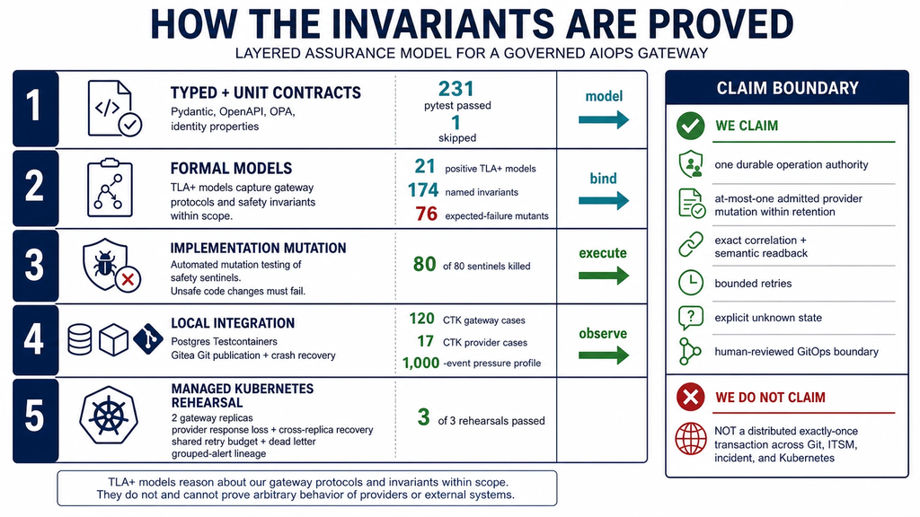

**Figure 4.** Schemas and unit tests check local behavior; mutation testing proves assertions detect meaningful changes; TLA+ checks state-machine invariants; Testcontainers and provider gates exercise real protocols; managed Kubernetes proves cross-replica behavior.

## Current evidence baseline

| Gate | Result |
| --- | --- |
| Python quality | 231 passed, 1 skipped |
| Positive TLA+ models | 21 models, 174 named invariants |
| Expected-failure TLA+ | 76 of 76 reached named first violation |
| Mutation sentinels | 80 of 80 killed |
| Postgres Testcontainers | Passed, including audit-chain verification |
| Gitea exact GitOps | Passed, including complete-diff rejection |
| Gitea crash recovery | Passed at branch, commit, and PR response-loss windows |
| Catalog GitOps plus Argo | 15 of 15 executable cases healthy |
| Local CTK gateway matrix | 120 of 120 |
| Local CTK provider matrix | 17 of 17 |
| Golden-path pressure | 1,000 events passed |
| Managed Kubernetes rehearsals | 3 of 3 |

```
run:
simplify-invariant-kernel-final-20260715T064345Z

image:
sha256:3cf3f8d9cfdb97e0263a1a94e768a386389c6e4a08a3f0f40c2797f83180cf71

source:
15c475087813f8e6aadd57e63762291e74452d0736ed3acf94dbdbe7cfe8ce89
```

| Managed case | Evidence |
| --- | --- |
| Cross-replica response-loss recovery | Distinct pod identities, one accepted object per provider, exact readback, no traffic on completed replay |
| Shared retry budget and dead letter | One accepted mutation, five durable attempts, later readback only, terminal dead letter, zero post-terminal traffic |
| Grouped-alert lineage | Order stable, changed membership changed audit lineage, same attempt/provider authority, no duplicate mutation |

This is strong bounded evidence, not a claim that every enterprise tenant or future provider version has been proven.

# 8. Invariants

| Invariant | Enforcement |
| --- | --- |
| No direct production mutation | Compiled catalog, OPA, typed plan, PR-only provider, read-only Argo |
| The model cannot authorize | Policy, approval, credentials, and effect executor remain outside it |
| Caller cannot substitute state | Post-policy calls carry `operationRef`; snapshot is server-owned |
| Caller cannot steal a handle | Snapshot binds `ownerCallerId` |
| Routes cannot skip prerequisites | Snapshot route requirements fail closed |
| Approval binds exact intent | Catalog, evidence, plan, policy, target, value, and attempt digests |
| Durable intent precedes effect | Outbox transition precedes provider mutation |
| One operation converges to one object | Unique key, fenced claim, deterministic correlation, exact readback |
| Unknown is not success | Accepted-write/lost-response remains ambiguous until readback |
| Human merge is the boundary | Draft PR, branch protection, no self-merge |
| Healthy is revision-specific | Argo checks expected revision |
| Audit derives from trusted state | Durable components, outbox, readback, and hash chain |
| One attempt may own multiple alert lineages | Separate attempt-to-audit-lineage relation |

# 9. Operator walkthrough

1. Open the Grafana rule/contact point and identify the Kestra webhook.
2. Open a Kestra execution; show full bodies only in evidence, plan, and policy.
3. Copy the `operationRef` from policy.
4. Query `aiops_state_records` for its operation snapshot.
5. Show `completedRoutes` and `revision` advancing.
6. Query the attempt and its audit-lineage relation.
7. Query every outbox row for the attempt.
8. Compare the draft PR’s repository, base, branch, path, and diff with approval.
9. Replay the webhook; verify the same authority and no extra provider object.
10. Inspect the expected Argo revision and audit event chain.

# 10. Source map

| Concern | Repository source |
| --- | --- |
| Canonical workflow | `examples/kestra-aiops/flows/catalog_remediation_aiops.yml` |
| Grafana fixture | `examples/kestra-aiops/fixtures/grafana-webhook-mimir-compactor.json` |
| Reviewed catalog | `catalog/remediation-catalog.yaml` |
| Catalog compiler | `examples/kestra-aiops/scripts/compile_remediation_catalog.py` |
| Runtime catalog | `examples/kestra-aiops/planner-gateway/catalog/remediation-catalog.compiled.json` |
| Request/response contracts | `aiops_control_plane/_request_contracts.py`, `contracts.py` |
| HTTP/caller authentication | `aiops_control_plane/http_server.py` |
| Operation references | `aiops_control_plane/operation_snapshots.py` |
| Identity | `aiops_control_plane/identity.py`, `identity_context.py` |
| Policy | `policies/aiops_policy.rego` |
| Approval/authorization | `aiops_control_plane/workflow/approvals.py`, `authorization.py` |
| Side-effect protocol | `aiops_control_plane/side_effects.py` |
| Postgres/schema | `aiops_control_plane/postgres_repository.py`, `alembic/versions/` |
| Git preparation/providers | `aiops_control_plane/git_proposal.py`, `providers/github.py`, `providers/_github/` |
| Argo readback | `aiops_control_plane/providers/argo.py` |
| Formal manifest | `aiops_control_plane/formal_contract.py` |

**One-sentence description:** Grafana detects a cataloged condition; Kestra sequences the protocol; the gateway turns evidence into one caller-, policy-, and approval-bound operation; Postgres makes external effects recoverable; Git and human review remain the mutation boundary; Argo and audit prove the result.